# Całkowanie metodą Riemanna i Monte Carlo

Agata

6.11.2021

Mamy dany wektor losowy $(X, Y)$ o standardowym dwuwymiarowym rozkładzie normalnym, gdzie $X$ i $Y$ są niezależne. Stąd łączna gęstość jest dana wzorem
$$f_{X,Y}(x,y)=\frac{1}{2\pi}e^{-\frac12(x^2+y^2)}, \ x,y\in \mathbb{R}.$$
Ponieważ zmienne losowe są niezależne, to rozkład łączny jest iloczynem rozkładów brzegowych, tj. $f_{X,Y}(x,y)=f_X(x)f_Y(y)$. Zadanie sprowadza się do obliczenia odpowiednich prawdopodobieństw i aby je wyznaczyć skorzystamy z twierdzenia

Twierdzenie 1

Jeśli $X,Y$ są ciągłymi zmiennymi losowymi, to prawdopodobieństwo, że $(X,Y) \in D, \ D\subseteq \mathbb{R}^2$ wyraża się wzorem
$$P((X,Y) \in D)=\int\!\!\!\int_{D} f_{X,Y}(x,y)dxdy.$$

Następnie policzymy odpowiednie całki, korzystając z metod numerycznych, a mianowicie aproksymacji Riemanna i metody Monte Carlo. Na końcu dokonamy porównania metod.

Przybliżmy po krótce obie metody.

**METODA APROKSYMACJI RIEMANNA**

Metoda Riemanna w $R^1$ polega na przybliżaniu pola pod wykresem polami prostokątów. W analogicznej wersji, w przypadku $R^2$, objętość między funkcją a obszarem całkowanie, przybliżamy licząc objętości prostopadłościanów. Dla uproszczenia rozważmy obszar całkowania, który jest kwadratem. Mamy policzyć całkę $\int_a^b\int_{a}^b g(x,y)dxdy$.

Zatem zaczynamy od podziału kwadratu $[a,b]\times [a,b]$ na mniejsze kwadraty, dzieląc $x\in[a,b]$ na $n$ odcinków i analogicznie $y$. Stąd dostajemy $n^2$ kwadratów o wymiarach $\frac{(b-a)}{n}\times \frac{(b-a)}{n}$. Należy policzyć wartość funkcji nad każdym kwadratem, w punktach środkowych kwadratu $x_{s_i}=\frac{x_{i+1}-x_{i}}{2}$, gdzie $i=0,1,2,...,n$ i $y_{s_i}=\frac{y_{i+1}-y_{i}}{2}$, gdzie $i=0,1,2,...,n$. Możemy przybliżyć całkę, korzystając ze wzoru
$$\int_a^b\int_{a}^b g(x,y)dxdy \approx \frac{(b-a)}{n} \frac{(b-a)}{n}\sum_{i=0}^n\sum_{j=0}^n g(x_{s_{i}},y_{s_{j}}).$$
Przy czym przybliżenie jest tym większe, im większe jest $n$.

Gdy obszar nie jest prostokątem, ale jest obszarem normalnym, dokonujemy podziału kwadratu zawierającego ten obszar a następnie wybieramy punkty spełniające równanie obszaru.

**METODA MONTE CARLO**

W przeciwieństwie do aproksymacji Riemanna metoda Monte Carlo korzysta z metod rachunku prawdopodobieństwa. Skupimy się na przedstawieniu metody Monte Carlo do całkowania funkcji dwóch zmiennych. Załóżmy, że mamy policzyć całkę $\int_a^b\int_{a}^b g(x,y)dxdy$, znów dla uproszczenia opisu na kwadracie.

Jeśli mamy wektor losowy $(X,Y)$ o gęstości łącznej $f(x,y)$, to wartość oczekiwaną możemy policzyć z definicji
$$E[g(X,Y)]=\int\!\!\!\int_{\mathbb{R}}g(x,y)f(x,y)dxdy.$$
Rozważmy próby losowe $X_1,...,X_n$ oraz $Y_1,...,Y_n$ o rozkładach jednostajnych na $[a,b]$. Gdy zmienne losowe $\xi_i,\eta_i\in U(0,1)$ dla $i=1,...,n$, to
$$X_i=a+\xi_i(b-a), \ \ \ \ Y_i=a+\eta_i(b-a).$$
Ponieważ zmienne losowe są niezależne, to ich łączna gęstość jest iloczynem gęstości brzegowych i $f(x,y)=(\frac{1}{b-a})^2$. Stąd
$$E[g(X,Y)]=\int\!\!\!\int_{\mathbb{R}}g(x,y)f(x,y)dxdy\approx \frac{(b-a)^2}{n}\sum_{i=1}^ng(X_i,Y_i).$$
Z Mocnego Prawa Wielkich Liczb wiemy, że
$$\lim_{n\to\infty}\frac{(b-a)^2}{n}\sum_{i=1}^ng(X_i,Y_i)=E[g(X,Y)] \ \ \text{ z pr. 1}$$
Zatem zbieżność metody zapewnia nam MPWL. Dodatkowo przybliżenie jest dokładniejsze, im większe jest $n$. Nad tempem zbieżności i poprawą dokładności zastanowimy się pod koniec.

Przedstawimy teraz instrukcję postępowania do obliczenia całki podwójnej na obszarze $D$ metodą Monte Carlo:

- ustalamy wymiary kwadratu zawierającego obszar całkowania - $[a,b]\times [a,b]$,
- losujemy dwa razy z rozkładu jednostajnego $U(0,1)$ $n$ liczb, otrzymując wektory $u_i, v_i, \ i=1,...,n$, i wyliczamy $x_i=a+u_i(b-a), \ \ y_i=a+v_i(b-a),$
- liczymy wartości $g(x_i,y_i)$ dla $ i=1,…,n$ i wyciągamy średnią,
- całka = pole obszaru * średnia wartość funkcji.

Mając za sobą wstęp teoretyczny, możemy przejść do obliczenia zadanych prawdopodobieństw. Całki zostały policzone numerycznie w programie R. Każde z trzech prawdopodobieństw wyznaczymy trzema sposobami: analitycznie, aproksymacją Riemanna i metodą Monte Carlo. Następnie porównamy zbieżność i dokładność obu numerycznych metod.

### Wyliczenie $P(0< X\leq1, 0< Y\leq1)$

Z Twierdzenia 1 dane prawdopodobieństwo możemy policzyć jako
$$P(0< X\leq1, 0< Y\leq1)= \int_0^1\int_0^1 \frac{1}{2\pi}e^{-\frac12(x^2+y^2)} dxdy.$$
Powyższej całki nie da się policzyć w sposób analityczny, dlatego skorzystajmy z niezależności $X$ i $Y$, i policzmy to prawdopodobieństwo jako iloczyn prawdopodobieństw i odczytamy wartości dystrybuanty rozkładu normalnego z tablic.

$$P(0< X\leq 1, 0< Y\leq1)=P(0< X\leq1)P(0< Y\leq 1)=[\phi(1)-\phi(0)]^2 \approx 0,116516.$$

Przyjrzyjmy się wynikom obliczeń całki w sposób numeryczny. Najpierw metoda aproksymacji Riemanna.

Zgodnie z opisem teoretycznym dokonaliśmy podziału obszaru całkowania, kwadratu, w naszym przypadku na 10000 kwadratów (oś X i Y dzielimy na m=100 odcinków). Następnie obliczamy wartość funkcji dla każdego kwadratu, ponieważ podział jest dość gęsty nie liczymy wartości w środku kwadratu, a w wierzchołkach. Nie ma to dużego wpływu na wartość całki.

```r
#a) calka na kwadracie metoda aproksymacji Riemanna
f <- function(x,y) 1/(2*pi)*exp(-0.5*(x^2+y^2))  #funkcja gestosci dwuwymiarowygo rozkladu normalnego gdy \rho=0
m=100 #gestosc podzialu obszaru
a=0
b=1
#podzial obszaru na kwadraty
x=seq(a,b,length.out=m)
y=seq(a,b,length.out=m)
punkty=expand.grid(x,y) #macierz wspólrzednych kwadratow
#obliczanie calki podwójnej: pole obszaru*wartosci funkcji w wylosowanych punktach
p=((b-a)/m)^2
sum(p*f(punkty[1],punkty[2]))
```

```
## [1] 0.1163723
```

W wyniku tego całkowania otrzymujemy wynik
$$\int_0^1\int_0^1 \frac{1}{2\pi}e^{-\frac12(x^2+y^2)} dxdy \approx 0,1163723.$$
Zobaczmy teraz wynik metody Monte Carlo

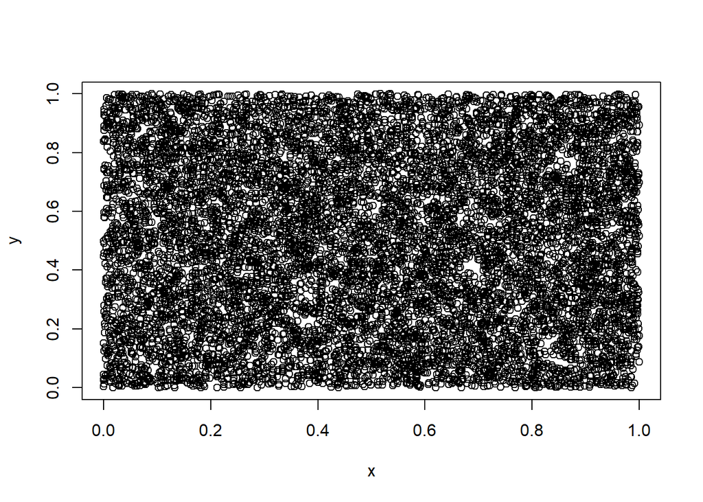

```r
#a) calka na kwadracie Monte Carlo
f <- function(x,y) 1/(2*pi)*exp(-0.5*(x^2+y^2))  #funkcja gestosci dwuwymiarowygo rozkladu normalnego gdy \rho=0
m = 10000 #liczba wylosowanych punktów

a=0
b=1
#losowanie liczb z U(a,b)
x= a+(b-a)*runif(m)
y= a+(b-a)*runif(m)
plot(x,y) #wykres wylosowanych punktów z obszaru calkowania
```

```r
#obliczanie calki podwójnej: pole obszaru*wartosci funkcji w wylosowanych punktach
(b-a)^2*mean(f(x,y))
```

```
## [1] 0.1162301
```

Porównajmy błędy względne obu metod, mając na uwadze wahania w metodzie MC.

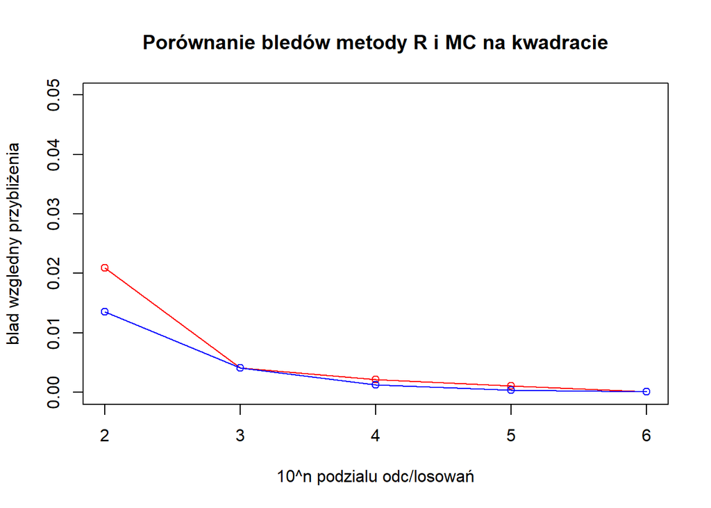

```r
#porównanie obu metod ze wzgledu na liczbe m
a=0
b=1
c1={}
c2={}
n <- c(100,1000,10000,100000,1000000) #liczba losowan punktu\liczba kwadratow w podziale
for (i in 1:5) {
  # MC
  x= a+(b-a)*runif(n[i])
  y= a+(b-a)*runif(n[i])
  c1[i] = (b-a)^2*mean(f(x,y))  #wektor calki MC dla różnych n
  # R
  x=seq(a,b,length.out=floor(sqrt(n[i]))) #bierzemy pierwiastek z n, bo chcemy mieć n kwadratów
  y=seq(a,b,length.out=floor(sqrt(n[i])))
  punkty={}
  punkty=expand.grid(x,y)
  p=((b-a)/floor(sqrt(n[i])))^2
  c2[i]=sum(p*f(punkty[1],punkty[2])) #wektor calki R dla różnych n

}

wartosc = 0.116516 # najlepsze przybliżenie wartosci calki
blad1 = abs(c1-wartosc)/wartosc #blad wzgledny MC
blad2 = abs(c2-wartosc)/wartosc #blad wzgledny R
plot(c(2,3,4,5,6), blad1, type = 'o', col = 'red',ylim = c(0,0.05),
     xlab = '10^n podzialu odc/losowań', ylab = 'blad wzgledny przybliżenia', main = 'Porównanie bledów metody R i MC na kwadracie')
  lines(c(2,3,4,5,6),blad2,type = 'o', col= 'blue')
```

Czerwona krzywa - wykres błędów względnych MC, niebieska - błędy R. Liczba losowań/podziału, to $10^2,10^3,10^4,10^5,10^6$.

Z wykresu możemy odczytać, że przy podziale/losowaniu dla $m=1000$ błąd względny jest na poziomie 0,5%. Na kwadracie nie ma dużych różnic między metodami.

### Wyliczenie $P(X^2 + Y^2<1)$

Zacznijmy od wyliczeń analitycznych
$$P(X^2 + Y^2<1)=\int\int_{K(0,1)} \frac{1}{2\pi}e^{-\frac12(x^2+y^2)} dxdy=$$
Zastosujemy współrzędne biegunowe

$x=r\cos\phi, \ y=r\sin\phi, \ x^2+y^2=r^2, \ |J|=r.$ Granice: $r\in (0,1], \ \phi \in(-\pi,\pi]$.
$$=\int_0^1\int_{-\pi}^{\pi} \frac{1}{2\pi}re^{-\frac12 r^2} drd\phi=\int_0^1r e^{-\frac12 r^2}dr=-e^{-\frac12 r^2}\Big|_0^1=1-\frac{1}{\sqrt e}\approx 0,3934693.$$

Możemy przeanalizować teraz metodę Riemanna

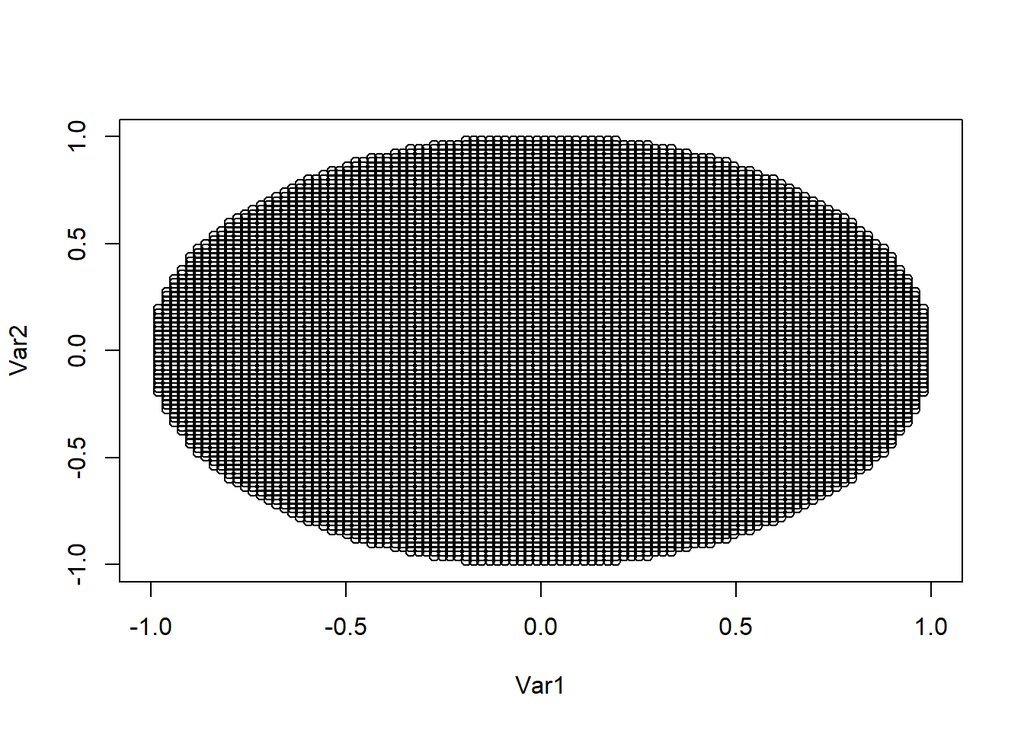

```r
#b) calka po kole metoda aproksymacji Riemanna
m=100 #gestosc podzialu obszaru
a=-1
b=1
#podzial obszaru na kwadraty
x=seq(a,b,length.out=m)
y=seq(a,b,length.out=m)
punkty=expand.grid(x,y)
kolo=punkty[punkty[1]^2+punkty[2]^2<1,] #obszar calkowania
plot(kolo,xlim=c(-1,1),ylim=c(-1,1)) #wykres obszaru
```

```r
#pole jednego kwadratu
p=(b-a)^2/(m^2)
#calka
sum(p*f(kolo[1],kolo[2]))
```

```
## [1] 0.3844913
```

Jedyną różnicą w kodzie w stosunku do podpunktu a) jest obszar całkowania. Musimy brać te kwadraty (punkty wyznaczające kwadraty), które należą do koła o środku 0 i promieniu 1. Otrzymujemy wynik
$$\int\int_{K(0,1)} \frac{1}{2\pi}e^{-\frac12(x^2+y^2)} dxdy \approx 0,3844913.$$
Teraz metodą Monte Carlo

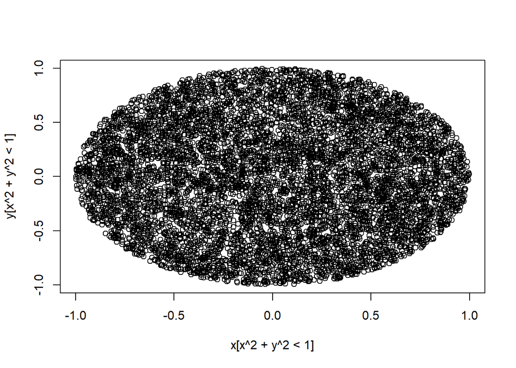

```r
#b) calka po kole Monte Carlo
f <- function(x,y) 1/(2*pi)*exp(-0.5*(x^2+y^2))  #funkcja gestosci dwuwymiarowygo rozkladu normalnego gdy \rho=0
m = 10000 #liczba wylosowanych punktów

a=-1
b=1
x= a+(b-a)*runif(m)
y= a+(b-a)*runif(m)
#pole obszaru calkowania
Pole_ob=(b-a)^2*length(x[x^2+y^2<1])/length(x)
plot(x[x^2+y^2<1],y[x^2+y^2<1])  #wykres wylosowanych punktów z obszaru calkowania
```

```r
#calka
Pole_ob*mean(f(x[x^2+y^2<1],y[x^2+y^2<1]))
```

```
## [1] 0.3914779
```

Zobaczymy porównanie błędów względnych dla obu metod ze względu na $m$.

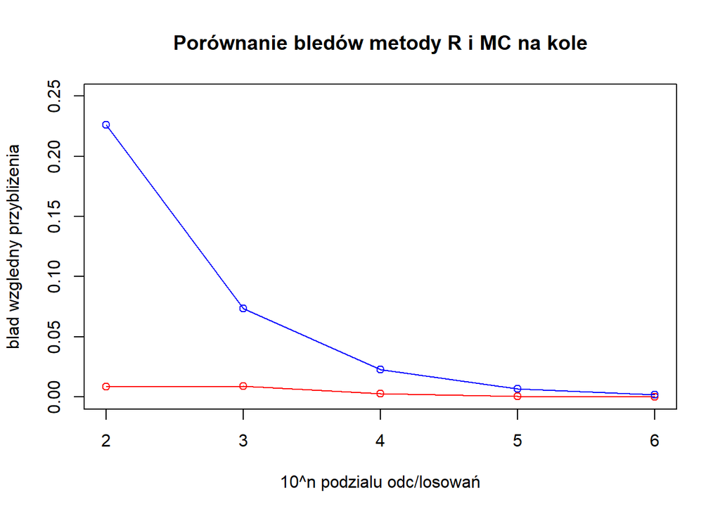

```r
#porównanie obu metod ze wzgledu na liczbe m
a=-1
b=1
c1={}
c2={}
n <- c(100,1000,10000,100000,1000000) #liczba losowan punktu\liczba kwadratow w podziale
for (i in 1:5) {
  # MC
  x= a+(b-a)*runif(n[i])
  y= a+(b-a)*runif(n[i])
  Pole_ob=(b-a)^2*length(x[x^2+y^2<1])/length(x)
  c1[i] =Pole_ob*mean(f(x[x^2+y^2<1],y[x^2+y^2<1]))  #wektor calki MC dla różnych n
  # R
  x=seq(a,b,length.out=floor(sqrt(n[i]))) #bierzemy pierwiastek z n, bo chcemy mieć n kwadratów
  y=seq(a,b,length.out=floor(sqrt(n[i])))
  punkty={}
  punkty=expand.grid(x,y)
  kolo=punkty[punkty[1]^2+punkty[2]^2<1,]
  p=((b-a)/floor(sqrt(n[i])))^2
  c2[i]=sum(p*f(kolo[1],kolo[2])) #wektor calki R dla różnych n

}

wartosc = 1-sqrt(exp(-1)) # najlepsze przybliżenie wartosci calki
blad1 = abs(c1-wartosc)/wartosc #blad wzgledny MC
blad2 = abs(c2-wartosc)/wartosc #blad wzgledny R
plot(c(2,3,4,5,6), blad1, type = 'o', col = 'red',ylim = c(0,0.25),
     xlab = '10^n podzialu odc/losowań', ylab = 'blad wzgledny przybliżenia', main = 'Porównanie bledów metody R i MC na kole')
lines(c(2,3,4,5,6),blad2,type = 'o', col= 'blue')
```

Czerwona krzywa - wykres błędów względnych MC, niebieska - błędy R. Liczba losowań/podziału, to $10^2,10^3,10^4,10^5,10^6.$

Widzimy, że w tym wypadku metoda MC wypada lepiej - generuje mniejszy błąd. Można to wytłumaczyć tym, że obszaru całkowania - koła - nie można podzielić na kwadraty. Dopiero przy dużym podziale, $m\geq 100000$, kwadraty z podziału “nie wystają” poza obszar.

### Wyliczenie $P(X>0, Y>0, X + Y<1)$

Całki nie da się wyliczyć analitycznie, dlatego skorzystamy z przybliżenia programu WolframAlpha:
$$P(X>0, Y>0, X + Y<1)=\int^1_0\int_{0}^{1-x} \frac{1}{2\pi}e^{-\frac12(x^2+y^2)} dxdy \approx 0,06773.$$
Kod programu:

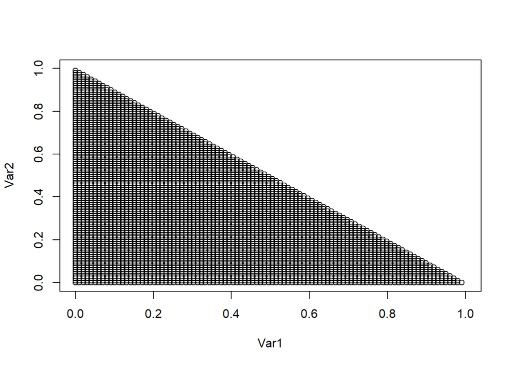

```r
#c) calka po trójkacie metoda aproksymacji Riemanna
m=100 #gestosc podzialu obszaru
a=0
b=1
#podzial obszaru na kwadraty
x=seq(a,b,length.out=m)
y=seq(a,b,length.out=m)
punkty=expand.grid(x,y)
trojkat=punkty[punkty[1]+punkty[2]<1,] #obszar calkowania
plot(trojkat,xlim=c(0,1),ylim=c(0,1)) #wykres obszaru
```

```r
#pole jednego kwadratu
p=(b-a)^2/(m^2)
#calka
sum(p*f(trojkat[1],trojkat[2]))
```

```
## [1] 0.0671654
```

Aproksymacja Riemanna
$$\int^1_0\int_{0}^{1-x} \frac{1}{2\pi}e^{-\frac12(x^2+y^2)} dxdy \approx 0,0671654.$$

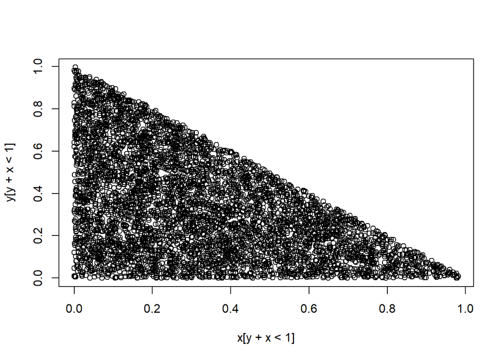

```r
#c) calka po trójkacie Monte Carlo
f <- function(x,y) 1/(2*pi)*exp(-0.5*(x^2+y^2))  #funkcja gestosci dwuwymiarowygo rozkladu normalnego gdy \rho=0
m = 10000 #liczba wylosowanych punktów

a=0
b=1
#losowanie liczb z U(a,b)
x= a+(b-a)*runif(m)
y= a+(b-a)*runif(m)
#pole obszaru calkowania
Pole_ob=(length(x[y+x<1]))/length(x)
plot(x[y+x<1],y[y+x<1]) #wykres wylosowanych punktów z obszaru calkowania
```

```r
#calka
Pole_ob*mean(f(x[y+x<1],y[y+x<1]))
```

```
## [1] 0.0686959
```

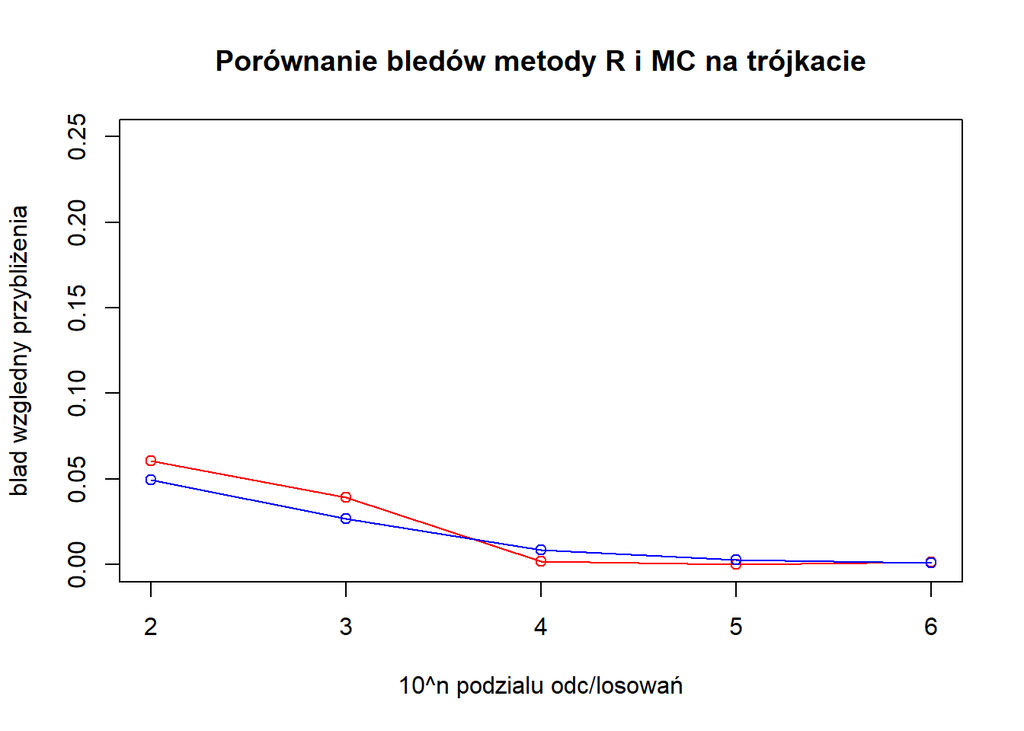

```r
#porównanie obu metod ze wzgledu na liczbe m
a=0
b=1
c1={}
c2={}
n <- c(100,1000,10000,100000,1000000) #liczba losowan punktu\liczba kwadratow w podziale
for (i in 1:5) {
  # MC
  x= a+(b-a)*runif(n[i])
  y= a+(b-a)*runif(n[i])
  Pole_ob=(length(x[y+x<1]))/length(x)
  c1[i] =Pole_ob*mean(f(x[x+y<1],y[x+y<1]))  #wektor calki MC dla różnych n
  # R
  x=seq(a,b,length.out=floor(sqrt(n[i]))) #bierzemy pierwiastek z n, bo chcemy mieć n kwadratów
  y=seq(a,b,length.out=floor(sqrt(n[i])))
  punkty={}
  punkty=expand.grid(x,y)
  trojkat=punkty[punkty[1]+punkty[2]<1,]
  p=((b-a)/floor(sqrt(n[i])))^2
  c2[i]=sum(p*f(trojkat[1],trojkat[2])) #wektor calki R dla różnych n

}

wartosc =0.06773 # najlepsze przybliżenie wartosci calki
blad1 = abs(c1-wartosc)/wartosc #blad wzgledny MC
blad2 = abs(c2-wartosc)/wartosc #blad wzgledny R
plot(c(2,3,4,5,6), blad1, type = 'o', col = 'red',ylim = c(0,0.25),
     xlab = '10^n podzialu odc/losowań', ylab = 'blad wzgledny przybliżenia', main = 'Porównanie bledów metody R i MC na trójkacie')
lines(c(2,3,4,5,6),blad2,type = 'o', col= 'blue')
```

Czerwona krzywa - wykres błędów względnych MC, niebieska - błędy R. Liczba losowań/podziału, to $10^2,10^3,10^4,10^5,10^6$.

Widzimy, że tu, podobnie jak w podpunkcie a, całki wyliczone obiema metodami dają wyniki o podobnej dokładności.

**WNIOSKI**

Metoda aproksymacji Riemanna i metoda Monte Carlo dają podobne rezultaty na regularnych, prostokątnych obszarach całkowania. MC daje różne wyniki przy każdorazowym wyliczaniu całki, przez co dla małych $m$ może czasem generować większy błąd. Z tego powodu bezpieczniejszą metodą jest metoda Riemanna. Gdy obszar całkowania nie jest regularny lub nie jest ograniczony prostymi, MC wypada znacznie lepiej.

**POPRAWA ZBIEŻNOŚCI ALGORYTMU MC**

Możemy teraz zadać sobie pytanie, czy jesteśmy w stanie uzyskać dokładniejszy wynik. Z treści MPWL wynika, że przybliżenie zbiega do faktycznej wartości przy $m\to\infty$, zatem naturalnym jest próbowanie zwiększenia dokładności poprzez zwiększanie ilości punktów tj. $m$. Jednakże z Centralnego Twierdzenia Granicznego wiemy, że odchylenie standardowe estymatora jest proporcjonalne do $\frac{1}{\sqrt{m}}$, zatem $\sigma(\cdot)=\frac{c}{\sqrt{m}}$, gdzie $c$ jest stałą. Z tego wynika, że aby zmniejszyć błąd o połowe należy wziąć poczwórnie dużą próbkę. Istnieją inne metody redukcji wariancji w celu poprawienia dokładności i my przyjrzymy się jednej, najprostszej metodzie - metodzie zmiennych antytetycznych.

Mamy policzyć całkę $\int\!\!\!\int_{D}g(x,y)dxdy$ i wiemy, że sprowadza się to do policzenia $E|g(X,Y)|$. Przypuśćmy, że mamy pary zmiennych losowych $(X,X'), (Y,Y')$ o jednakowym rozkładzie i nie zakładamy ich niezależności. Wówczas
$$Var\Big(\frac{g(X,Y)+g(X',Y')}{2}\Big)=\frac12Var(X,Y)\Big[1+corr(g(X,Y),g(X',Y'))\Big]=\frac12\sigma^2(1+\rho).$$
Zatem, aby zmniejszyć wariancję, zmienne losowe muszą być ujemnie skorelowane.

W naszym przypadku, zamiast losować $m$ zmiennych losowych $X_i\sim U(0,1)$ i analogicznie dla $Y$, możemy wylosować $\frac m2$ zmiennych losowych $X_i\sim U(0,1)$ i wyliczyć $X'_i=1-X_i$ (analogicznie dla $Y$). Wtedy para $(X_i,X'_i)$ ma ten sam rozkład i jest ujemnie skorelowana.

Sprawdźmy, dla przykładu a), jak zachowuje się wartość całki i wariancja w zwykłej, i zmodyfikowanej metodzie MC.

```r
# Porównanie zwyklej metody Monte Carlo z zmodyfikowana wersja - zmienne antytetyczne

f <- function(x,y) 1/(2*pi)*exp(-0.5*(x^2+y^2))  #funkcja gestosci dwuwymiarowygo rozkladu normalnego gdy \rho=0
m <- c(100, 1000, 10000, 100000) #liczba wylosowanych punktów

a=0
b=1
w1 = {}
w2 = {}
war1 ={}
war2 = {}
for (i in 1:4) {
  #tradycyjna MC
  x= a+(b-a)*runif(m[i])
  y= a+(b-a)*runif(m[i])
  w1[i] = (b-a)^2*mean(f(x,y))
  war1[i] = var(f(x,y))

  #MC ze zmiennymi antytetycznymi
  x1= runif(m[i]/2)
  y1= runif(m[i]/2)
  x2=1-x1
  y2=1-y1
  w2[i] = (b-a)^2*mean((f(x1,y1)+f(x2,y2))/2)
  war2[i] = var((f(x1,y1)+f(x2,y2))/2)
}
```

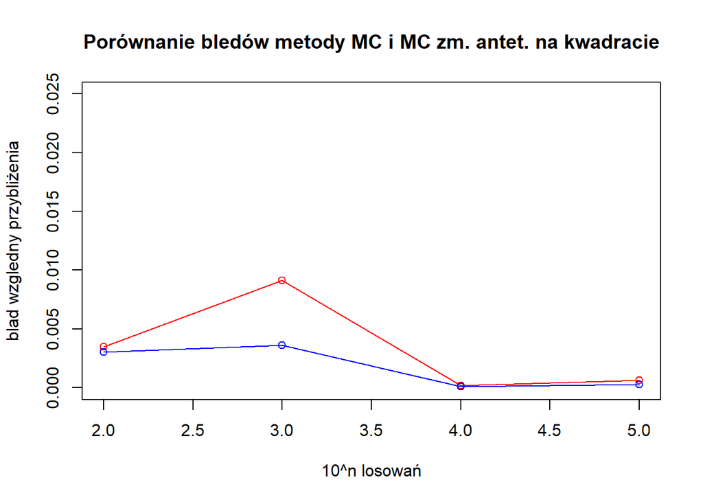

```r
wartosc = 0.116516 # najlepsze przybliżenie wartosci calki
blad1 = abs(w1-wartosc)/wartosc #blad wzgledny MC
blad2 = abs(w2-wartosc)/wartosc #blad wzgledny MC Zm. antytetyczne
plot(c(2,3,4,5), blad1, type = 'o', col = 'red',ylim = c(0,0.025),
     xlab = '10^n losowań', ylab = 'blad wzgledny przybliżenia', main = 'Porównanie bledów metody MC i MC zm. antet. na kwadracie')
lines(c(2,3,4,5),blad2,type = 'o', col= 'blue')
```

Czerwona krzywa - tradycyjna metoda MC; niebieska - metoda MC z zastosowaniem zmiennych antytetycznych.

```r
podsumowanie <- data.frame("liczba losowań"=m,"wartosc MC"=w1, "wariancja MC"=war1,
                           "blad wzgl MC"=blad1,"wartosc MC-z.antyt."=w2, "wariancja MC-z.antyt."=war2,
                           "blad wzgl MC-z.antyt."=blad2)
podsumowanie
```

```
##   liczba.losowań wartosc.MC wariancja.MC blad.wzgl.MC wartosc.MC.z.antyt.
## 1          1e+02  0.1169211 0.0005486029 0.0034771729           0.1161650
## 2          1e+03  0.1154503 0.0005451098 0.0091460131           0.1169378
## 3          1e+04  0.1165372 0.0005567807 0.0001821627           0.1165028
## 4          1e+05  0.1164431 0.0005508542 0.0006258262           0.1164831
##   wariancja.MC.z.antyt. blad.wzgl.MC.z.antyt.
## 1          2.251676e-05          0.0030127159
## 2          2.569094e-05          0.0036197009
## 3          2.612127e-05          0.0001130470
## 4          2.627091e-05          0.0002824412
```

Jak można zauważyć, zmodyfikowana metoda Monte Carlo jest dokładniejsza i zmniejsza wariancję, w naszym przypadku, o rząd wielkości.

**Źródło**

- Jakubowski, Sztencel *Wstęp do teorii prawdopodobieństwa*
- DeGroot, Schervish *Probability and Statistics*
- https://mst.mimuw.edu.pl/lecture.php?lecture=sst&part=Ch9#S3
- https://www.scratchapixel.com/lessons/mathematics-physics-for-computer-graphics/monte-carlo-methods-in-practice/monte-carlo-integration
- https://towardsdatascience.com/monte-carlo-integration-in-python-over-univariate-and-multivariate-functions-12615dd252fa
- https://cs.dartmouth.edu/wjarosz/publications/dissertation/appendixA.pdf